# Tugas Analisis Multimedia: Audio, Gambar, Video

**Mata Kuliah:** Sistem & Teknologi Multimedia  
**Nama:** Lois Novel E Gurning  
**NIM:** 122140098

## Deskripsi Tugas

Tugas ini bertujuan untuk memahami representasi dasar data multimedia (audio, gambar, dan video) melalui praktik langsung memuat data, visualisasi, dan ekstraksi informasi fundamental. Anda akan bekerja dengan tiga jenis media berbeda untuk menganalisis karakteristik temporal (audio), spasial (gambar), dan spatio-temporal (video).

Fokus tugas adalah pada pemahaman konsep dasar representasi multimedia dan kemampuan interpretasi hasil visualisasi, **bukan** pada manipulasi atau transformasi lanjutan data multimedia.

## ⚠️ CATATAN PENTING: PRESENTASI ACAK & KEJUJURAN AKADEMIK

**Sebagian mahasiswa akan dipilih secara ACAK untuk presentasi singkat** (5-10 menit) menjelaskan kode dan interpretasi hasil mereka. Jika Anda:

- Tidak mampu menjelaskan kode yang Anda kumpulkan
- Hanya menyalin-tempel tanpa pemahaman
- Bergantung sepenuhnya pada AI tanpa memahami konsep

**Maka nilai tugas Anda akan diberikan 0 (nol).**

Gunakan referensi dan AI sebagai alat bantu pembelajaran, tetapi pastikan Anda memahami setiap baris kode dan dapat menjelaskan logika di baliknya.

```python
# Import Library (Satu-satunya sel kode dalam template ini)
import numpy as np
import matplotlib
import matplotlib.pyplot as plt
import librosa
import soundfile as sf
from PIL import Image
import cv2
from IPython.display import Audio, HTML, display
import os

# Set matplotlib untuk menampilkan plot inline
%matplotlib inline

# Tampilkan versi library untuk dokumentasi
print("Library versions:")
print(f"NumPy: {np.__version__}")
print(f"Matplotlib: {matplotlib.__version__}")
print(f"Librosa: {librosa.__version__}")
print(f"OpenCV: {cv2.__version__}")

# Tambahkan import lain jika diperlukan saat mengerjakan tugas
```

```
Library versions:
NumPy: 2.2.5
Matplotlib: 3.10.1
Librosa: 0.11.0
OpenCV: 4.10.0
```

## Petunjuk Umum Pengerjaan

### 📋 Cara Menggunakan Template

- Gunakan notebook ini sebagai kerangka kerja utama
- Tulis penjelasan (markdown) **SEBELUM** menaruh kode agar maksud dan tujuan jelas
- Tambahkan sel kode di tempat yang sudah disediakan (tandai dengan TODO)
- Semua plot/gambar harus diberi judul, label sumbu, dan keterangan singkat

### 📊 Standar Visualisasi

- Setiap plot harus memiliki judul yang deskriptif
- Label sumbu X dan Y harus jelas
- Gunakan colorbar untuk plot yang memerlukan skala warna
- Berikan interpretasi singkat setelah setiap visualisasi

### 📂 Struktur Data yang Direkomendasikan

- Buat folder `data/` di direktori yang sama dengan notebook
- Gunakan nama file yang deskriptif (contoh: `audio_musik_piano.wav`, `gambar_pemandangan_gunung.jpg`)
- Dokumentasikan sumber data jika menggunakan dataset publik

### ⚠️ Larangan

- **Jangan** menaruh seluruh pekerjaan dalam satu sel kode yang sangat panjang
- **Jangan** menempel hasil output tanpa interpretasi atau analisis
- **Jangan** bergantung sepenuhnya pada AI - pahami dan kuasai kode Anda

### 🎯 Persiapan Presentasi Acak

- Pastikan Anda memahami setiap baris kode yang ditulis
- Latih menjelaskan logika dan alur pemikiran Anda
- Siapkan penjelasan untuk setiap visualisasi dan interpretasinya

## Checklist Kelengkapan (Centang ✅ saat selesai)

### 🎵 Bagian Audio

- [✅] Muat audio dan tampilkan metadata (durasi, sample rate, jumlah kanal)
- [✅] Tampilkan waveform dengan label sumbu yang jelas
- [✅] Tampilkan spectrogram dalam skala log-dB dengan colorbar
- [✅] Tampilkan MFCC (minimal 13 koefisien) sebagai heatmap
- [✅] Berikan interpretasi dan analisis untuk setiap visualisasi audio

### 🖼️ Bagian Gambar

- [✅] Tampilkan gambar dengan benar dalam format RGB
- [✅] Tampilkan informasi dasar (dimensi, jumlah kanal, dtype)
- [✅] Tampilkan histogram warna untuk channel R, G, B
- [✅] Berikan analisis hubungan histogram dengan kesan visual gambar

### 📹 Bagian Video

- [✅] Tampilkan metadata video (resolusi, fps, frame count, durasi)
- [✅] Tampilkan 3 frame representatif (awal, tengah, akhir)
- [✅] Konversi BGR ke RGB dengan benar untuk visualisasi
- [✅] Analisis kesesuaian parameter video dengan use case

### 📝 Analisis & Dokumentasi

- [✅] Setiap bagian memiliki interpretasi dan analisis ringkas
- [✅] Perbandingan representasi ketiga jenis media
- [✅] Kesimpulan pembelajaran dan refleksi
- [✅] Semua sumber data dan referensi dicantumkan

# Pendahuluan

## Apa itu Data Multimedia?

Data multimedia adalah informasi yang dikodekan dalam berbagai format untuk merepresentasikan dunia nyata:

- **Audio (1D)**: Sinyal satu dimensi yang berubah terhadap waktu
  - Contoh: musik, suara, speech
  - Representasi: amplitudo vs waktu
- **Gambar (2D)**: Matriks nilai intensitas dalam ruang dua dimensi
  - Contoh: foto, ilustrasi, grafik
  - Representasi: intensitas pixel pada koordinat (x,y)
- **Video (2D + Waktu)**: Rangkaian frame (gambar) yang ditampilkan berurutan
  - Contoh: film, rekaman, animasi
  - Representasi: frame berubah terhadap waktu dengan frame rate tertentu

## Tujuan Tugas

Memahami representasi dasar dan teknik visualisasi fundamental untuk setiap jenis media multimedia, termasuk:

- Cara memuat dan membaca file multimedia
- Ekstraksi informasi metadata yang penting
- Visualisasi yang informatif dan mudah dipahami
- Interpretasi hasil analisis secara kontekstual

## Cara Kerja

1. Isi setiap bagian sesuai instruksi yang diberikan
2. Tambahkan sel kode di tempat yang ditandai dengan "TODO"
3. Berikan interpretasi dan analisis setelah setiap visualisasi
4. Pastikan semua plot memiliki judul, label, dan keterangan yang jelas

# Bagian A — Audio

### A1. Deskripsi Data

**TODO:** Jelaskan audio yang akan Anda analisis:

- Jenis audio: Musik
- Sumber: Dataset publik
- Format file: MP3
- Alasan pemilihan: Musik merupakan jenis audio yang umum dan gampang ditemukan.

**Path file:** `data/audio_musik_gitar.mp3`

### A2. TODO: Muat & Metadata

**Instruksi:** Tulis kode untuk memuat file audio dan menampilkan metadata dasar:

- Sample rate (Hz)
- Durasi (detik)
- Jumlah kanal (mono/stereo)
- Jumlah total sampel

**Catatan:** Jika file MP3 bermasalah saat loading, gunakan format WAV sebagai alternatif.

Kode berikut digunakan untuk memuat file audio (`audio_musik_gitar.mp3`) yang disimpan pada folder `data`.  
Dengan library **librosa**, audio akan dibaca lalu dihitung beberapa informasi penting (*metadata*) seperti:

- **Sample rate** → jumlah sampel per detik (Hz).
- **Durasi audio** → total panjang audio dalam detik.
- **Channels** → apakah audio mono (1 channel) atau stereo (2 channel).
- **Total samples** → jumlah keseluruhan data sampel audio.

```python
audio_path = os.path.join(os.getcwd(), "data", "audio_musik_gitar.mp3")

try:
    # Load data
    y, sr = librosa.load(audio_path)

    # Hitung metadata
    duration = len(y) / sr
    channels = 'Mono (1 channel)' if y.ndim == 1 else f'Stereo ({y.ndim} channels)'
    total_samples = len(y)

    # Tampilkan metadata
    print("📋 AUDIO METADATA")
    print("=" * 40)
    print(f"🎵 Sample rate: {sr:,} Hz")
    print(f"⏱️ Duration: {duration:.2f} seconds")
    print(f"📻 Channels: {channels}")
    print(f"🔢 Total samples: {total_samples:,}")

except FileNotFoundError:
    print("❌ Error: Audio file not found. Please check the path and file name.")
except Exception as e:
    print(f"❌ Error loading audio: {str(e)}")
```

```
📋 AUDIO METADATA
========================================
🎵 Sample rate: 22,050 Hz
⏱️ Duration: 10.58 seconds
📻 Channels: Mono (1 channel)
🔢 Total samples: 233,280
```

### A3. TODO: Waveform

**Instruksi:** Plot waveform audio dengan:

- Sumbu X: waktu (detik)
- Sumbu Y: amplitudo
- Judul dan label sumbu yang jelas

Kode berikut akan menampilkan waveform dari file audio (`audio_musik_gitar.mp3`) dengan:

- Sumbu X: Waktu (detik)
- Sumbu Y: Amplitudo (-1 sampai 1)
- Judul yang informatif
- Grid untuk memudahkan pembacaan

**Analisis yang diperlukan:** Jelaskan apa yang Anda lihat dari waveform (pola amplitudo, bagian keras/pelan, dll.)

Berdasarkan waveform, diperoleh kesimpulan bahwa audio berfluktuasi antara -0.3 hingga +0.3 menunjukkan volume audio yang cukup teratur. Sumbu X pada waveform tersebut menunjukkan waktu dalam detik dari audio (durasi audio), yaitu sama dengan 10.58 detik, sementara sumbu Y menunjukkan amplitudo sinyal (berada dalam rentang -1 hingga 1). Amplitudo merupakan tinggi gelombang yang dapat menunjukkan kuat-lemahnya suara. Semakin kuat suara maka amplitudo akan semakin tinggi/besar, dan sebaliknya. Misal detik 1 pada waveform di atas, terlihat amplitudo kecil, yang artinya suara pada audio sampel saat itu pelan. Dari waveform tersebut, kita juga dapat melihat sebuah pola teratur. Di awal audio, terlihat pola tinggi, rendah, tinggi, sangat kecil, rendah, sangat kecil, kemudian tinggi. Pola teratur dari waveform audio ini sangat mencirikan bahwa audio yang digunakan adalah musik, karena musik memiliki ritme/beat/ketukan.

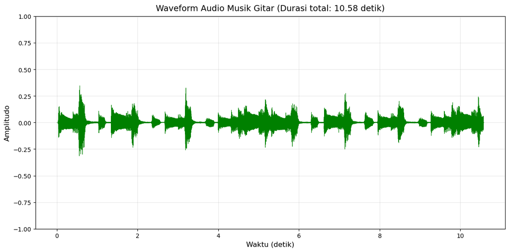

```python
# Load data
audio_path = os.path.join(os.getcwd(), "data", "audio_musik_gitar.mp3")
y, sr = librosa.load(audio_path)

# Create time array for x-axis
time = np.arange(0, len(y)) / sr

# Create figure with larger size
plt.figure(figsize=(12, 6))

# Plot waveform
plt.plot(time, y, color='green', linewidth=0.5)

# Add title and labels
duration = len(y)/sr
plt.title(f'Waveform Audio Musik Gitar (Durasi total: {duration:.2f} detik)', pad=10, size=14)
plt.xlabel('Waktu (detik)', size=12)
plt.ylabel('Amplitudo', size=12)

# Add grid for better readability
plt.grid(True, alpha=0.3)

# Set y-axis limits
plt.ylim([-1, 1])

# Adjust layout
plt.tight_layout()

# Show plot
plt.show()
```

Berikutnya yang bisa diidentifikasi melalui waveform adalah ZCR (Zero Crossing Rate). Kode dan visualisasi dapat dilihat di bawah ini. ZCR merupakan jumlah berapa kali sinyal audio melalui garis nol (berubah dari nilai positif ke negatif, dan sebaliknya). ZCR berfungsi untuk mengekstrak fitur sederhana tentang apakah audio cenderung bernada atau berisik/ritmis. Diperoleh data sebagai berikut:

- Rata-rata ZCR: 0.0490 (4.90%)
- Nilai minimum ZCR: 0.0186 (1.86%)
- Nilai maksimum ZCR: 0.1338 (13.38%)
- Standar deviasi ZCR: 0.0259 (2.59%)

Nilai ZCR tersebut dikategorikan sebagai rendah yang menandakan audio didominasi frekuensi rendah. Pada konteks musik, ZCR rendah bisa terjadi pada nada instrumen tonal seperti piano, gitar, biola, vokal bernada. Terdapat juga pola berulang yang mencerminkan struktur melodi/musik.

```
Rata-rata ZCR: 0.0490
Nilai minimum ZCR: 0.0186
Nilai maksimum ZCR: 0.1338
Standar deviasi ZCR: 0.0259
```

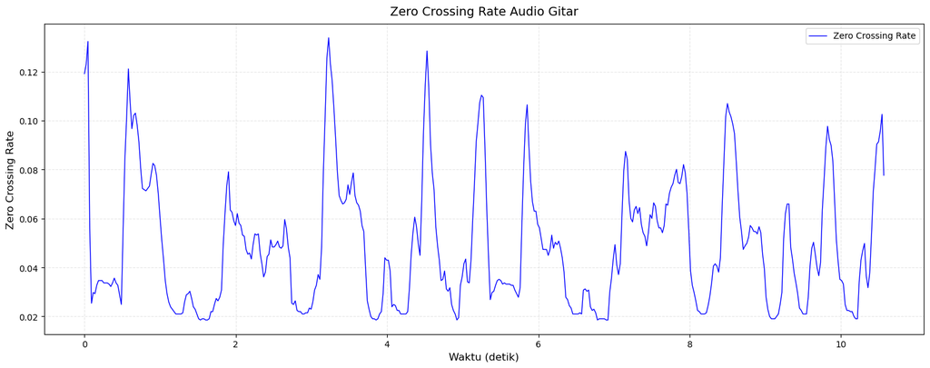

```python
# Load data
audio_path = os.path.join(os.getcwd(), "data", "audio_musik_gitar.mp3")
y, sr = librosa.load(audio_path)

# Hitung ZCR
frame_length = 2048  # Panjang frame untuk analisis
hop_length = 512     # Jarak antar frame

# Hitung ZCR menggunakan librosa
zcr = librosa.feature.zero_crossing_rate(y, frame_length=frame_length,hop_length=hop_length)

# Buat array waktu untuk sumbu x
times = librosa.times_like(zcr)

# Buat plot
plt.figure(figsize=(15, 6))

# Plot ZCR
plt.plot(times, zcr[0], label='Zero Crossing Rate', color='blue', linewidth=1)

# Tambahkan judul dan label
plt.title('Zero Crossing Rate Audio Gitar', size=14, pad=10)
plt.xlabel('Waktu (detik)', size=12)
plt.ylabel('Zero Crossing Rate', size=12)

# Tambahkan grid dan legend
plt.grid(True, alpha=0.3, linestyle='--')
plt.legend()

# Statistik ZCR
print(f"Rata-rata ZCR: {zcr.mean():.4f}")
print(f"Nilai minimum ZCR: {zcr.min():.4f}")
print(f"Nilai maksimum ZCR: {zcr.max():.4f}")
print(f"Standar deviasi ZCR: {zcr.std():.4f}")

plt.tight_layout()
plt.show()
```

### A4. TODO: Spectrogram log-dB

**Instruksi:** Hitung STFT dan tampilkan spectrogram dalam skala log-dB:

- Gunakan parameter standar (n_fft=1024, hop_length=256)
- Tampilkan dengan colorbar
- Label sumbu: waktu (detik) dan frekuensi (Hz)

**Analisis yang diperlukan:** Jelaskan perbedaan informasi yang didapat dari spectrogram dibanding waveform.

Waveform dan Spektogram dapat digunakan untuk memvisualisasikan audio, tetapi informasi yang diberikan berbeda. Waveform memvisualisasikan audio dalam domain waktu dengan sumbu horizontal menunjukkan waktu dan sumbu vertikal menunjukkan amplitudo. Dari waveform, kita dapat memperoleh informasi terkait durasi, bentuk gelombang, Zero Cross Rate, serta intensitas suara, tetapi informasi mengenai frekuensi yang membentuk suara tidak terlihat. Informasi terkait frekuensi dapat diamati dengan spektogram. Spektrogram merepresentasikan audio dalam domain waktu–frekuensi, di mana sumbu horizontal menunjukkan waktu, sumbu vertikal menunjukkan frekuensi, dan warna atau tingkat kecerahan merepresentasikan intensitas energi suara. Dengan spektrogram, kita bisa melihat frekuensi dominan dari audio, perubahan nada, timbre, serta pola spektral yang muncul sepanjang waktu. Oleh karena itu, waveform lebih cocok untuk memahami kapan dan seberapa kuat suara terjadi, sedangkan spectrogram lebih cocok untuk mengetahui nada atau frekuensi apa saja yang ada di dalam suara dan bagaimana perubahannya dari waktu ke waktu.

Sebagai contoh adalah (`audio_musik_gitar.mp3`) yang saya gunakan ini. Melalui spektogram, dapat diperoleh informasi berikut:

- Intensitas suara audio terkuat berada pada range frekuensi 0-2000 Hz (warna kuning-hijau)
- Terdapat garis-garis konsisten di bagian bawah yang menunjukkan nada dasar gitar (sekitar 200-500 Hz)
- Timbre (warna khas suara) gitar dapat dikenali dengan adanya harmonik (muncul sebagai garis-garis horizontal/mendatar pada spektogram)
- Harmonik-harmonik muncul hingga sekitar 8000 Hz dengan intensitas yang semakin melemah ke 10000 Hz
- Setiap pola vertikal berjarak sekitar 0.5-1 detik, menunjukkan tempo permainan gitar
- Pola berulang vertikal muncul teratur menunjukkan ciri khas audio musik

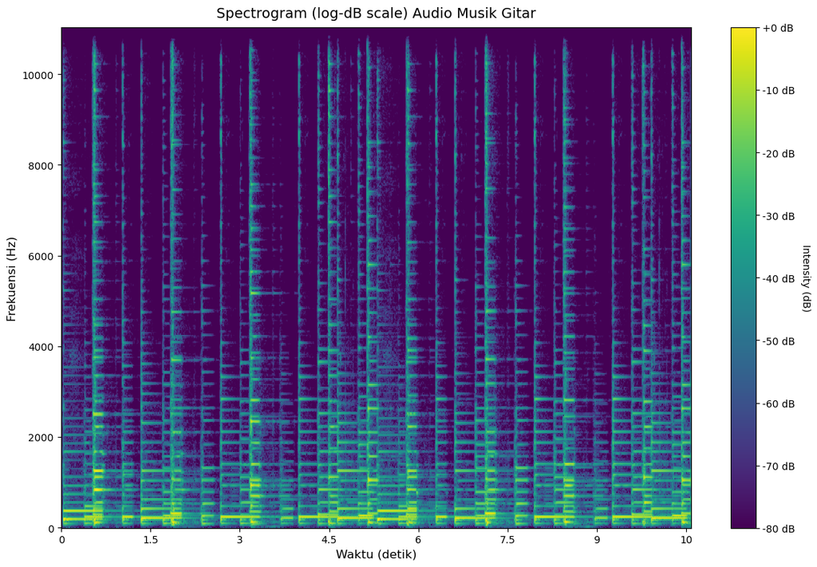

[output not shown]

```python
# Load audio file
audio_path = os.path.join(os.getcwd(), "data", "audio_musik_gitar.mp3")
y, sr = librosa.load(audio_path)

# Compute STFT (Short-Time Fourier Transform) with Hann window
D = librosa.stft(y, n_fft=1024, hop_length=256, window='hann')

# Convert to log-scaled DB units
DB = librosa.amplitude_to_db(abs(D), ref=np.max)

# Calculate parameters
time_resolution = hop_length / sr  # in seconds
freq_resolution = sr / n_fft  # in Hz
magnitude_shape = D.shape
magnitude_range = (np.abs(D).min(), np.abs(D).max())

# Create figure with larger size
plt.figure(figsize=(12, 8))

# Display spectrogram
img = librosa.display.specshow(
    DB,
    sr=sr,
    hop_length=256,
    x_axis='time',
    y_axis='hz',
    cmap='viridis'
)

# Add colorbar
cbar = plt.colorbar(img, format='%+2.0f dB')
cbar.set_label('Intensity (dB)', rotation=270, labelpad=15)

# Add title and labels
plt.title('Spectrogram (log-dB scale) Audio Musik Gitar', pad=10, size=14)
plt.xlabel('Waktu (detik)', size=12)
plt.ylabel('Frekuensi (Hz)', size=12)

# Adjust layout
plt.tight_layout()

# Show plot
plt.show()
# Print information
print("STFT Parameters & Information:")
print("=" * 40)
print(f"FFT size (n_fft): {n_fft} samples")
print(f"Hop length: {hop_length} samples")
print(f"Window function: {window}")
print(f"Magnitude shape: {magnitude_shape} (frequencies × time frames)")
print(f"Time resolution: {time_resolution*1000:.2f} ms")
print(f"Frequency resolution: {freq_resolution:.2f} Hz")
print(f"Magnitude range: [{magnitude_range[0]:.2e}, {magnitude_range[1]:.2e}]")
```

### A5. TODO: MFCC

**Instruksi:** Hitung dan tampilkan minimal 13 koefisien MFCC sebagai heatmap:

- Sumbu X: waktu (frame)
- Sumbu Y: koefisien MFCC (1-13)
- Gunakan colorbar dan judul yang jelas

**Analisis yang diperlukan:** Interpretasi sederhana: apakah pola MFCC stabil atau berubah-ubah? Apa potensi maknanya?

Pola MFCC yang dihasilkan oleh (`audio_musik_gitar.mp3`) cenderung teratur/stabil pada koefisien 0-3, sementara pada koefisien 4-12 memiliki pola yang sedikit agak bervariasi (nyaris samar). Hal ini dapat berarti suara relatif tetap dalam jangka waktu tertentu. Kondisi ini biasanya muncul ketika timbre audio tidak mengalami banyak variasi, misalnya saat gitar dipetik lalu nadanya sustain.

[figure not shown]

```
Mel-spectrogram Statistics:
Shape: (128, 456)
Mean: -55.00
Std: 19.05
Min: -80.00
Max: 0.00

MFCC Statistics:
Shape: (13, 456)
Mean: -24.46
Std: 139.34
Min: -755.46
Max: 211.65
```

```python
# Load audio file
audio_path = os.path.join(os.getcwd(), "data", "audio_musik_gitar.mp3")
y, sr = librosa.load(audio_path)

# Define parameters
n_fft = 1024
hop_length = 256
n_mfcc = 13

# Create figure with two subplots
plt.figure(figsize=(15, 12))

# Plot 1: Mel-spectrogram
plt.subplot(2, 1, 1)
mel_spect = librosa.feature.melspectrogram(y=y, sr=sr, n_mels=128, n_fft=n_fft)
mel_spect_db = librosa.power_to_db(mel_spect, ref=np.max)
img1 = librosa.display.specshow(
    mel_spect_db,
    x_axis='time',
    y_axis='mel',
    sr=sr,
    fmax=8000,
    cmap='viridis'
)
plt.colorbar(img1, format='%+2.0f dB', label='Amplitude')
plt.title('Mel-Spectrogram (dB)', pad=10, size=14)
plt.xlabel('Waktu (detik)', size=12)
plt.ylabel('Frekuensi Mel', size=12)

# Plot 2: MFCC
plt.subplot(2, 1, 2)
mfccs = librosa.feature.mfcc(y=y, sr=sr, n_mfcc=n_mfcc, n_fft=n_fft)
img2 = librosa.display.specshow(
    mfccs,
    x_axis='time',
    y_axis='frames',
    hop_length=hop_length,
    sr=sr,
    cmap='viridis'
)
plt.colorbar(img2, format='%+2.0f', label='Magnitude')
plt.title(f'MFCC Coefficients Audio Musik Gitar ({n_mfcc} koefisien)', pad=10, size=14)
plt.xlabel('Waktu (detik)', size=12)
plt.ylabel('Koefisien MFCC', size=12)

# Adjust layout
plt.tight_layout()
plt.show()

# Print statistics
print("\nMel-spectrogram Statistics:")
print(f"Shape: {mel_spect_db.shape}")
print(f"Mean: {mel_spect_db.mean():.2f}")
print(f"Std: {mel_spect_db.std():.2f}")
print(f"Min: {mel_spect_db.min():.2f}")
print(f"Max: {mel_spect_db.max():.2f}")

print("\nMFCC Statistics:")
print(f"Shape: {mfccs.shape}")
print(f"Mean: {mfccs.mean():.2f}")
print(f"Std: {mfccs.std():.2f}")
print(f"Min: {mfccs.min():.2f}")
print(f"Max: {mfccs.max():.2f}")
```

### A6. Analisis Ringkas (Wajib)

**Jawab pertanyaan berikut:**

1. **Perbedaan insight:** Apa perbedaan informasi yang didapat dari waveform versus spectrogram?

   *Jawaban Anda:*

   Waveform dan spectrogram sama-sama berguna untuk memahami audio, tetapi dari sudut yang berbeda. Waveform menunjukkan perubahan amplitudo terhadap waktu sehingga kita bisa melihat ritme, intensitas, dan durasi suara, misalnya bagian keras atau lembut serta pola ketukan. Sementara itu, spectrogram memperlihatkan bagaimana frekuensi terbagi sepanjang waktu, sehingga kita bisa melihat nada dasar, harmonik, timbre audio, dan perubahan nada. Pada contoh audio gitar, waveform menampilkan pola ritme petikan, sedangkan spectrogram memperlihatkan frekuensi fundamental di sekitar 200–500 Hz, serta harmonik hingga 8000 Hz. Singkatnya, waveform lebih tepat untuk analisis ritme/beat/intensitas, sedangkan spectrogram lebih cocok untuk melihat karakter frekuensi dan warna suara.
2. **Pembelajaran dari MFCC:** Apa yang Anda pelajari dari visualisasi MFCC audio ini?

   *Jawaban Anda:*

   Dari visualisasi MFCC (`audio_musik_gitar.mp3`), dapat terlihat bahwa gitar memiliki timbre yang konsisten, ditunjukkan oleh koefisien rendah yang relatif stabil sepanjang waktu. Hal ini mencerminkan karakter suara gitar yang khas dan terjaga. Pada koefisien yang lebih tinggi, tampak variasi halus yang menggambarkan detail perubahan harmonik saat nada sustain atau saat terjadi transisi antar nada. Mel-spectrogram juga menunjukkan bahwa energi terbesar terkonsentrasi pada frekuensi rendah hingga menengah (0–2000 Hz), sesuai dengan karakteristik gitar.

# Bagian B — Gambar

### B1. Deskripsi Data

**TODO:** Jelaskan gambar yang akan Anda analisis:

- Jenis gambar: Pemandangan
- Sumber: Foto sendiri
- Format file: JPG
- Alasan pemilihan: Gambar pemandangan jalanan memiliki objek dan warna yang beragam di dalamnya.

**Path file:** `data/gambar_pemandangan_jalanan.jpg`

### B2. TODO: Baca & Tampilkan (RGB)

**Instruksi:** Baca gambar dan tampilkan dengan benar dalam format RGB:

- Pastikan konversi warna benar (ingat perbedaan BGR vs RGB di OpenCV)
- Berikan judul yang deskriptif
- Hilangkan axis untuk tampilan yang bersih

**Analisis yang diperlukan:** Jelaskan gambar secara ringkas (objek dominan, kondisi pencahayaan, komposisi warna).

Gambar menunjukkan suasana jalanan dengan objek dominan berupa langit dan jalanan/trotoar, truk, beberapa sepeda motor, serta bangunan ruko di sisi kiri. Di sisi kanan tampak papan reklame bertuliskan “Vape Dream” dan beberapa orang yang sedang berkendara atau berada di sekitar jalan. Kondisi pencahayaan terlihat terang alami menjelang sore, dengan langit biru dan sedikit semburat jingga. Komposisi warna didominasi oleh kuning (truk dan tembok), biru (langit dan dinding bangunan), serta abu-abu (aspal dan trotoar).

[figure not shown]

```python
try:
    # Read image using OpenCV (BGR format)
    img_path = os.path.join(os.getcwd(), "data", "gambar_pemandangan_jalanan.jpg")
    img_bgr = cv2.imread(img_path)

    if img_bgr is None:
        raise FileNotFoundError("Image could not be loaded")

    # Convert BGR to RGB
    img_rgb = cv2.cvtColor(img_bgr, cv2.COLOR_BGR2RGB)

    # Create figure with specified size
    plt.figure(figsize=(12, 8))

    # Display image
    plt.imshow(img_rgb)

    # Add title
    plt.title('Pemandangan Jalanan (RGB)', pad=10, size=14)

    # Remove axes
    plt.axis('off')

    # Adjust layout
    plt.tight_layout()

    # Show plot
    plt.show()

except FileNotFoundError as e:
    print(f"Error: {str(e)}")
    print("Please check if the image file exists in the data directory")
except Exception as e:
    print(f"An error occurred: {str(e)}")
```

### B3. TODO: Informasi Dasar

**Instruksi:** Tampilkan informasi metadata gambar:

- Dimensi (Height × Width)
- Jumlah kanal
- Tipe data (dtype)
- Mode warna (jika relevan)
- Ukuran file dalam memori

**Analisis yang diperlukan:** Jelaskan mengapa informasi ini penting untuk tahap preprocessing atau analisis lanjutan.

Informasi metadata seperti dimensi, jumlah kanal, tipe data, mode warna, dan ukuran file sangat penting dalam tahap preprocessing maupun analisis lanjutan gambar karena menentukan bagaimana data tersebut dapat diproses. Dimensi (height × width) memastikan ukuran gambar sesuai dengan kebutuhan model atau algoritma, misalnya CNN biasanya memerlukan ukuran input tertentu. Jumlah kanal dan mode warna penting karena memengaruhi representasi informasi visual; gambar grayscale hanya punya 1 kanal, sementara gambar RGB punya 3 kanal, dan ini memengaruhi cara ekstraksi fitur dilakukan. Tipe data (dtype) berhubungan dengan rentang nilai piksel—apakah 0–255 (uint8) atau 0–1 (float32), yang berpengaruh pada normalisasi data dan kesesuaian dengan library untuk analisis. Ukuran file dalam memori penting untuk efisiensi komputasi. Gambar beresolusi tinggi dengan banyak kanal bisa memakan banyak memori sehingga perlu diresize atau dikompresi agar pemrosesan lebih cepat dan tidak membebani sistem.

```python
try:
    # Read image using OpenCV
    img_path = os.path.join(os.getcwd(), "data", "gambar_pemandangan_jalanan.jpg")
    img = cv2.imread(img_path)

    if img is None:
        raise FileNotFoundError("Image could not be loaded")

    # Get image information
    height, width, channels = img.shape
    dtype = img.dtype
    mode_warna = "RGB (setelah konversi dari BGR)" if channels == 3 else "Grayscale"
    size_bytes = img.nbytes
    size_mb = size_bytes / (1024 * 1024)  # Convert to MB

    # Print metadata with formatting
    print("📸 IMAGE METADATA")
    print("=" * 40)
    print(f"📏 Dimensi: {height} × {width} pixels")
    print(f"🎨 Jumlah kanal: {channels}")
    print(f"💾 Tipe data: {dtype}")
    print(f"🎯 Mode warna: {mode_warna}")
    print(f"📦 Ukuran memori: {size_bytes:,} bytes ({size_mb:.2f} MB)")

except FileNotFoundError as e:
    print(f"Error: {str(e)}")
    print("Please check if the image file exists in the data directory")
except Exception as e:
    print(f"An error occurred: {str(e)}")
```

```
📸 IMAGE METADATA
========================================
📏 Dimensi: 4624 × 3468 pixels
🎨 Jumlah kanal: 3
💾 Tipe data: uint8
🎯 Mode warna: RGB (setelah konversi dari BGR)
📦 Ukuran memori: 48,108,096 bytes (45.88 MB)
```

### B4. TODO: Histogram Warna

**Instruksi:** Tampilkan histogram distribusi intensitas untuk channel R, G, B:

- Range: 0-255
- Plot terpisah atau overlay dengan warna sesuai channel
- Label sumbu: intensitas pixel dan frekuensi
- Legend yang jelas

**Analisis yang diperlukan:** Analisis: channel mana yang dominan? Bagaimana kontras gambar? Seperti apa sebaran intensitasnya?

Berdasarkan histogram RGB dari (`gambar_pemandangan_jalanan.jpg`), diperoleh:

1. Dominasi Channel
- Channel biru (Blue) tampak paling dominan di sisi kanan histogram (intensitas tinggi, >180). Artinya, gambar punya banyak area dengan warna kebiruan terang (langit).
- Channel hijau (Green) juga cukup kuat di rentang menengah (sekitar 80–160).
- Channel merah (Red) cenderung kuat di intensitas rendah–menengah (sekitar 50–120), tapi tidak sekuat hijau dan biru di bagian intensitas tinggi.

Jadi secara umum, biru mendominasi, disusul hijau, lalu merah.

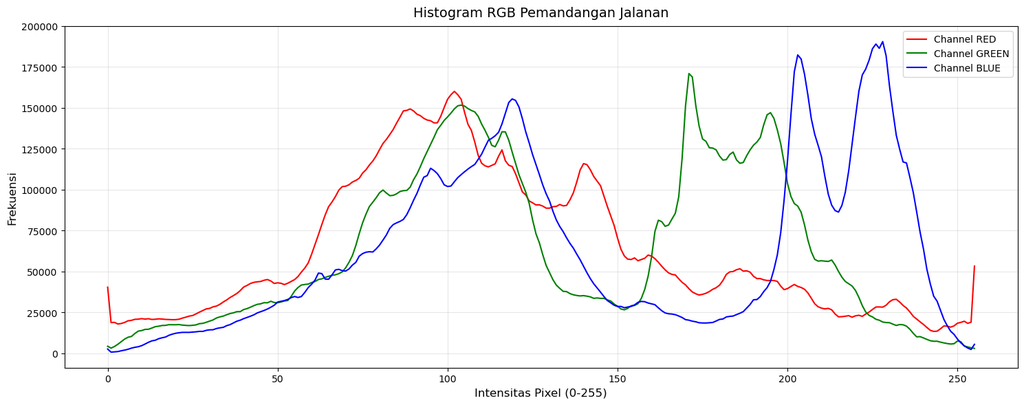

```
Statistik Kanal Warna:
========================================

Kanal RED:
Mean: 116.96
Std Dev: 53.68
Min: 0
Max: 255

Kanal GREEN:
Mean: 134.04
Std Dev: 54.05
Min: 0
Max: 255

Kanal BLUE:
Mean: 150.28
Std Dev: 62.10
Min: 0
Max: 255
```

```python
try:
    # Read image using OpenCV
    img_path = os.path.join(os.getcwd(), "data", "gambar_pemandangan_jalanan.jpg")
    img_bgr = cv2.imread(img_path)

    if img_bgr is None:
        raise FileNotFoundError("Image could not be loaded")

    # Convert BGR to RGB
    img_rgb = cv2.cvtColor(img_bgr, cv2.COLOR_BGR2RGB)

    # Create figure with larger size
    plt.figure(figsize=(15, 6))

    # Calculate histograms for each channel
    colors = ('red', 'green', 'blue')
    for i, color in enumerate(colors):
        hist = cv2.calcHist([img_rgb], [i], None, [256], [0, 256])
        plt.plot(hist, color=color, label=f'Channel {color.upper()}')

    # Customize plot
    plt.title('Histogram RGB Pemandangan Jalanan', pad=10, size=14)
    plt.xlabel('Intensitas Pixel (0-255)', size=12)
    plt.ylabel('Frekuensi', size=12)
    plt.legend()
    plt.grid(True, alpha=0.3)

    # Adjust layout and display
    plt.tight_layout()
    plt.show()

    # Print channel statistics
    print("\nStatistik Kanal Warna:")
    print("=" * 40)
    for i, color in enumerate(colors):
        channel = img_rgb[:,:,i]
        print(f"\nKanal {color.upper()}:")
        print(f"Mean: {channel.mean():.2f}")
        print(f"Std Dev: {channel.std():.2f}")
        print(f"Min: {channel.min()}")
        print(f"Max: {channel.max()}")

except FileNotFoundError as e:
    print(f"Error: {str(e)}")
    print("Please check if the image file exists in the data directory")
except Exception as e:
    print(f"An error occurred: {str(e)}")
```

### B5. Analisis Ringkas (Wajib)

**Jawab pertanyaan berikut:**

**Relasi histogram dengan kesan visual:** Apa hubungan antara pola histogram yang Anda lihat dengan kesan visual gambar (terang/gelap, warna dominan, kontras)?

# Bagian C — Video

### C1. Deskripsi Data

**TODO:** Jelaskan video yang akan Anda analisis:

- Jenis video: Pemandangan
- Sumber: Rekaman sendiri
- Durasi target: ± 16 detik
- Alasan pemilihan: Pada video terdapat kombinasi cahaya terang dengan latar gelap, serta pola gerakan yang dinamis.

**Path file:** `data/video_pemandangan_kembangapi.mp4`

### C2. TODO: Baca & Metadata

**Instruksi:** Baca video dengan OpenCV dan tampilkan metadata:

- Resolusi (Width × Height)
- Frame rate (fps)
- Jumlah total frame
- Durasi (detik)
- Klasifikasi resolusi (HD, Full HD, 4K, dll.)

**Analisis yang diperlukan:** Jelaskan pentingnya parameter-parameter tersebut untuk analisis video atau aplikasi tertentu.

Parameter-parameter tersebut sangat penting karena memengaruhi kualitas visual, detail informasi, dan beban komputasi dalam analisis maupun aplikasi. Resolusi (Width × Height) menentukan detail gambar, di mana resolusi tinggi lebih baik untuk mendeteksi objek kecil. Frame rate (fps) menunjukkan kelancaran gerakan; fps tinggi dibutuhkan untuk aplikasi real-time seperti pelacakan atau gaming. Jumlah total frame dan durasi (detik) menunjukkan panjang video—semakin panjang, semakin besar kebutuhan memori dan waktu proses. Klasifikasi resolusi (HD, Full HD, 4K, dll.) memberi standar kualitas visual; misalnya 4K cocok untuk pengawasan detail, sedangkan resolusi rendah lebih efisien untuk streaming atau analisis sederhana. Dengan memahami parameter ini, analisis bisa lebih tepat sekaligus efisien.

```python
from datetime import timedelta

try:
    # Read video file
    video_path = os.path.join(os.getcwd(), "data", "video_pemandangan_kembangapi.mp4")
    cap = cv2.VideoCapture(video_path)

    if not cap.isOpened():
        raise FileNotFoundError("Error: Could not open video file")

    # Get video properties
    width = int(cap.get(cv2.CAP_PROP_FRAME_WIDTH))
    height = int(cap.get(cv2.CAP_PROP_FRAME_HEIGHT))
    fps = int(cap.get(cv2.CAP_PROP_FPS))
    total_frames = int(cap.get(cv2.CAP_PROP_FRAME_COUNT))
    duration = total_frames / fps

    # Determine resolution classification
    def classify_resolution(w, h):
        if w >= 3840 and h >= 2160:
            return "4K (2160p)"
        elif w >= 2560 and h >= 1440:
            return "2K (1440p)"
        elif w >= 1920 and h >= 1080:
            return "Full HD (1080p)"
        elif w >= 1280 and h >= 720:
            return "HD (720p)"
        else:
            return "SD"

    resolution_class = classify_resolution(width, height)

    # Print metadata with formatting
    print("📹 VIDEO METADATA")
    print("=" * 40)
    print(f"📐 Resolusi: {width} × {height} pixels")
    print(f"⚡ Frame rate: {fps} fps")
    print(f"🎞️ Total frames: {total_frames:,}")
    print(f"⏱️ Durasi: {duration:.2f} seconds ({str(timedelta(seconds=duration))})")
    print(f"📺 Klasifikasi: {resolution_class}")

    # Release video capture
    cap.release()

except FileNotFoundError as e:
    print(f"Error: {str(e)}")
    print("Please check if the video file exists in the data directory")
except Exception as e:
    print(f"An error occurred: {str(e)}")
    if 'cap' in locals():
        cap.release()
```

```
📹 VIDEO METADATA
========================================
📐 Resolusi: 1920 × 1080 pixels
⚡ Frame rate: 30 fps
🎞️ Total frames: 495
⏱️ Durasi: 16.50 seconds (0:00:16.500000)
📺 Klasifikasi: Full HD (1080p)
```

### C3. TODO: Tampilkan 3 Frame (Awal–Tengah–Akhir)

**Instruksi:** Ambil dan tampilkan 3 frame representatif:

- Frame pertama (index 0)
- Frame tengah (index ~total_frame/2)
- Frame terakhir (index total_frame-1)
- **Konversi BGR→RGB** sebelum ditampilkan
- Subplot dengan judul frame dan timestamp

**Analisis yang diperlukan:** Deskripsikan perbedaan visual antar frame dan apa yang dapat dipelajari dari sampel frame ini!

**Perbedaan visual:**

1. Frame 0 (0.00s)
- Kembang api terlihat mulai meledak
- Ledakan masih terlihat kecil (ledakan awal)
2. Frame 247 (8.22s)
- Ledakan kembang api mencapai puncak dengan intensitas cahaya paling tinggi
- Pola sebaran kembang api mulai melebar dan berbentuk seperti payung/mekar
- Intensitas cahaya meningkat signifikan dibanding frame awal
- Background bangunan mulai terlihat lebih jelas karena pencahayaan dari kembang api
3. Frame 494 (16.45s)
- Ledakan kembang api selesai
- Percikan cahaya sebelumnya telah menghilang total, menyisakan suasana gelap, dan pencahayaan hanya dari lampu bangunan

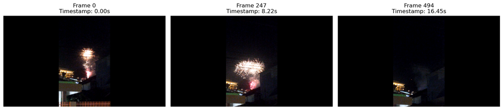

```python
# Buka video dengan os.path.join
video_path = os.path.join(os.getcwd(), "data", "video_pemandangan_kembangapi.mp4")
cap = cv2.VideoCapture(video_path)

# Dapatkan total frame dan FPS
total_frames = int(cap.get(cv2.CAP_PROP_FRAME_COUNT))
fps = cap.get(cv2.CAP_PROP_FPS)

# Tentukan frame yang akan diambil
frames_to_extract = [
    0,                    # Frame pertama
    total_frames // 2,    # Frame tengah
    total_frames - 1      # Frame terakhir
]

# List untuk menyimpan frame dan timestamp
frames = []
timestamps = []

# Ekstrak frame yang diinginkan
for frame_idx in frames_to_extract:
    cap.set(cv2.CAP_PROP_POS_FRAMES, frame_idx)
    ret, frame = cap.read()
    if ret:
        # Konversi BGR ke RGB
        frame_rgb = cv2.cvtColor(frame, cv2.COLOR_BGR2RGB)
        frames.append(frame_rgb)
        # Hitung timestamp dalam detik
        timestamp = frame_idx / fps
        timestamps.append(f"{timestamp:.2f}s")

# Tutup video
cap.release()

# Tampilkan frame dalam subplot
plt.figure(figsize=(15, 5))

for idx, (frame, timestamp) in enumerate(zip(frames, timestamps)):
    plt.subplot(1, 3, idx + 1)
    plt.imshow(frame)
    plt.title(f'Frame {frames_to_extract[idx]}\nTimestamp: {timestamp}')
    plt.axis('off')

plt.tight_layout()
plt.show()
```

### C4. Analisis Ringkas (Wajib)

**Jawab pertanyaan berikut:**

**Kesesuaian parameter:** Apakah fps dan resolusi video ini sesuai untuk use case pilihan Anda (misalnya: media sosial, kuliah daring, presentasi, dll.)? Jelaskan alasan singkat.

*Jawaban Anda:*

Use case: Sosial Media

Parameter video dengan resolusi Full HD (1920×1080), dan frame rate 30 fps sangat cocok untuk media sosial. Frame rate 30 fps sudah cukup halus untuk menampilkan gerakan kembang api sekaligus hemat bandwidth, sehingga lancar di berbagai perangkat. Resolusi Full HD memberi kualitas gambar yang tajam dan sesuai standar modern, serta kompatibel dengan berbagai platform seperti Instagram, YouTube, Facebook, dan Twitter.

# Perbandingan & Kesimpulan

## Perbandingan Representasi Media

**TODO:** Bandingkan secara ringkas representasi dan visualisasi ketiga media:

### Audio (1D - Temporal)

- Representasi: Sinyal satu dimensi berupa gelombang amplitudo terhadap waktu
- Visualisasi utama: Waveform, spectrogram, dan MFCC
- Informasi yang diperoleh: Pola ritme, intensitas, nada, frekuensi dominan, timbre, serta perubahan suara dari waktu ke waktu.

### Gambar (2D - Spasial)

- Representasi: Matriks pixel dengan nilai intensitas (grayscale) atau kanal warna (RGB), dimensi height × width × channels.
- Visualisasi utama: Tampilan citra, dan histogram distribusi intensitas per channel.
- Informasi yang diperoleh: Komposisi warna dan distribusi intensitas, serta kontras dan brightness dari histogram.

### Video (2D + Waktu - Spatio-temporal)

- Representasi: Rangkaian frame (gambar 2D) yang berurutan dalam waktu.
- Visualisasi utama: Frame sampling (awal, tengah, akhir)
- Informasi yang diperoleh: Perubahan scene/objek terhadap waktu, serta kualitas dan kelancaran gerakan dari fps.

## Refleksi Pembelajaran

### 3 Poin yang Saya Pelajari:

1. Analisis audio dengan spektogram untuk melihat pola suara, STFT.
2. Analisis spasial pada gambar dengan histogram.
3. MCFF dan Mel-Scale.

### 2 Hal yang Masih Membingungkan/Ingin Diperdalam:

1. MCFF
2. Spektogram

## Sumber Data & Referensi

**TODO:** Cantumkan semua sumber data dan referensi yang digunakan:

- **Audio:** [Acoustic Guitar Loop (Pixabay)](https://pixabay.com/sound-effects/acoustic-guitar-loop-f-91bpm-132687/)
- **Gambar:** Milik sendiri
- **Video:** Milik sendiri
- **Referensi AI & diskusi:** [Transkrip ChatGPT I](https://chatgpt.com/share/68c82020-cd18-8003-b31b-580a7170dffb) , [Transkrip ChatGPT II](https://chatgpt.com/share/68c8290f-aed8-8012-9e4d-f145c80c54c4)

# Rubrik Penilaian

## Distribusi Bobot Penilaian

| **Aspek Penilaian** | **Bobot** | **Deskripsi** |
| --- | --- | --- |
| **Kelengkapan** | **35%** | Semua langkah inti dikerjakan sesuai checklist |
| **Kualitas Visualisasi** | **20%** | Judul, label sumbu, colorbar, legend, keterbacaan plot |
| **Analisis & Interpretasi** | **30%** | Kemampuan interpretasi hasil, bukan sekadar output mentah |
| **Kerapihan & Struktur** | **10%** | Markdown jelas, kode modular, dokumentasi baik |
| **Orisinalitas & Penguasaan** | **5%** | Pemahaman saat presentasi acak |

## Detail Kriteria Penilaian

### 🏆 Kelengkapan (35%)

- ✅ Semua 4 visualisasi audio (metadata, waveform, spectrogram, MFCC)
- ✅ Semua 3 visualisasi gambar (display RGB, metadata, histogram)
- ✅ Semua 2 visualisasi video (metadata, frame extraction)
- ✅ Analisis ringkas untuk setiap bagian

### 📊 Kualitas Visualisasi (20%)

- Plot memiliki judul yang informatif dan deskriptif
- Label sumbu X dan Y jelas dan sesuai
- Colorbar/legend tersedia jika diperlukan
- Ukuran plot proporsional dan mudah dibaca

### 🧠 Analisis & Interpretasi (30%)

- Interpretasi menunjukkan pemahaman konsep
- Analisis kontekstual, bukan sekadar deskripsi output
- Mampu menghubungkan hasil dengan teori
- Refleksi pembelajaran yang thoughtful

### 📝 Kerapihan & Struktur (10%)

- Markdown terstruktur dengan heading yang konsisten
- Kode bersih, terkompartemen, dan mudah dibaca
- Dokumentasi yang memadai
- Flow logical dari satu bagian ke bagian lain

### 🎯 Orisinalitas & Penguasaan (5%)

- **PENTING:** Jika saat presentasi acak Anda tidak mampu menjelaskan kode yang Anda tulis atau menunjukkan ketergantungan buta pada AI/copy-paste, **nilai tugas akan dianggap 0**.
- Kemampuan menjelaskan logika dan alur pemikiran
- Pemahaman konsep di balik implementasi kode

## Proporsi Penilaian Total

- Proporsi penilaian hanya 80%, 20% lagi akan didasarkan pada kecepatan pengumpulan tugas
- Sehingga: 0.8 * penilaian dosen + nilai waktu pengumpulan

# Aturan Kejujuran Akademik

## 📖 Penggunaan Referensi & AI yang Diperbolehkan

Anda **BOLEH** menggunakan:

- ✅ Dokumentasi resmi library (NumPy, Matplotlib, Librosa, OpenCV)
- ✅ Tutorial dan contoh kode dari sumber terpercaya
- ✅ AI tools (ChatGPT, GitHub Copilot, dll.) sebagai **alat bantu pembelajaran**
- ✅ Diskusi dengan teman untuk pemahaman konsep

## ⚠️ Syarat & Batasan WAJIB

Namun Anda **HARUS**:

- 🧠 **Memahami setiap baris kode** yang Anda masukkan ke notebook
- 📝 **Menulis interpretasi dengan kata-kata sendiri**, bukan hasil copy-paste
- 📚 **Mencantumkan sumber data dan referensi** yang digunakan, termasuk transkrip percakapan dengan AI dalam link atau teks
- 🎯 **Mampu menjelaskan logika dan alur pemikiran** saat presentasi acak

## ❌ Pelanggaran yang Berakibat Nilai 0

- **Plagiarisme atau penyalinan buta** dari sumber manapun
- **Copy-paste kode tanpa pemahaman** dan tidak dapat menjelaskan
- **Menggunakan AI untuk mengerjakan seluruh tugas** tanpa pembelajaran personal
- **Tidak dapat menjawab pertanyaan dasar** tentang kode yang dikumpulkan
- **Menyalin pekerjaan teman** atau bekerjasama dalam pengerjaan individual

## 🎯 Persiapan Presentasi Acak

**Kemungkinan pertanyaan yang akan ditanyakan:**

- "Jelaskan mengapa Anda menggunakan parameter ini di STFT?"
- "Apa arti dari pola yang terlihat di MFCC?"
- "Mengapa perlu konversi BGR ke RGB?"
- "Interpretasikan hasil histogram yang Anda buat"
- "Bagaimana cara kerja spectrogram?"

**Tips sukses:**

- Pahami konsep dasar setiap teknik yang digunakan
- Latih menjelaskan dengan bahasa sederhana
- Siapkan justifikasi untuk setiap pilihan parameter
- Kuasai interpretasi setiap visualisasi yang dibuat

# Panduan Pengumpulan

## 📁 Berkas yang Harus Dikumpulkan

### Wajib:

1. **Notebook Jupyter** (.ipynb) dengan nama: `NIM_Nama_TugasMultimedia.ipynb`
   - Contoh: `123456789_JohnDoe_TugasMultimedia.ipynb`
2. **PDF hasil render dari notebook**

## 📅 Informasi Pengumpulan

## ✅ Checklist Sebelum Submit

- [✅] Semua cell sudah dijalankan dan menampilkan output
- [✅] Nama file sesuai format: `NIM_Worksheet2.ipynb` dan `NIM_Worksheet2.pdf`
- [✅] Semua TODO sudah diisi dengan lengkap
- [✅] Analisis dan interpretasi sudah ditulis untuk setiap bagian
- [✅] Sumber data dan referensi sudah dicantumkan

### Export ke PDF:

- File → Save and Export Notebook As → HTML
- Buka HTML di browser -> Save as PDF